# Todos pela Popularidade:

## Introdução

## Introdução

A Pandemia instaura um jogo de esquiva de responsabilidade.

Analisaremos as posições em relação ao enfretamento da pandemia adotadas pelas duas casas do Poder Legislativo brasileiro, matizado pela ideologia dos partidos e sua proximidade com o governo. Busca-se saber o posicionamento dos parlamentares com relação às ações e posturas do Governo Federal, e ao distanciamento social.

## O custo de apoiar o Presidente

Apoiar o distanciamento poderia ser entendido como importante ação da oposição ao Governo, não sendo surpreendente a sua constatação empírica. Não tão claro assim é se o engajamento em um conflito aberto varia de acordo com o a popularidade do Presidente. Mais especificamente: à medida que a popularidade do Presidente cresce, é possível observar o efeito previsto pela literatura de não confrontação (HETHERINGTON; NELSON, 2003)?

## O custo de apoiar o Presidente

Com relação àqueles próximos ao Presidente, resta se perguntar qual seria o incentivo a apoiá-lo, tendo como pressuposto o radicalismo das condutas contra o distanciamento, e o altíssimo custo de estar associado a elas. Por essa razão, seria plausível supor que os apoiadores do Presidente no parlamento escolhessem evitar a sua defesa, cuidar da pandemia em outros aspectos relevantes e com baixa exposição a temas polêmicos e impopulares.

## O custo de apoiar o Presidente

É de se imaginar, igualmente, que o apoio do Presidente tenha um custo, e que os recursos federais enviados para âmbito local possuam forte poder explicativo para o posicionamento individual e coletivo dos parlamentares (PEREIRA; MUELLER, 2002, 2003). No entanto, o presente trabalho utilizará como variável explicativa a popularidade do Presidente, tentando se aproximar a troca de recursos através dos partidos que compõem sua base de apoio – ideia operacionalizada pela ocupação de ministérios no gabinete.

## Hipóteses

## Hipóteses

H1: À medida que a popularidade do Presidente diminui, aumentam ainda mais os ataques já realizados por partidos de esquerda.

H2: A Direita é a única que defende o Presidente durante momentos mais sensíveis de sua popularidade, apesar de discutir menos a sua responsabilidade sobre o tema. Além disso, à medida que a popularidade presidencial cresce, esse espectro tende a discutir mais o tema e a apoiar mais intensamente o Presidente.

H3: O Centro possui maior mobilidade qualitativa (ataque/defesa) de seus posicionamentos em função da popularidade presidencial.

## Metodologia e dados

## Coleta

Os discursos proferidos em plenário no período de março até o fim agosto de 2020 foram analisados para fins do presente trabalho, tendo por critério de seleção a pertinência com o tema da pandemia

Os discursos foram analisados de forma manual. A coleta e a análise se deram no mês de setembro de 2020. Através das buscas, os discursos foram estruturados em forma de tabela, lidos e classificados de acordo com as categorias que serão apresentadas.

## Amostra

### Tabela 1 - Câmara dos Deputados

| Ideologia | Total | Covid | % Covid do total | % Covid | Covid e Executivo | % Covid e Executivo | % Covid sem Executivo | % Demais assuntos |
| --- | --- | --- | --- | --- | --- | --- | --- | --- |
| Esquerda | 5007 | 2444 | 48,8% | 57,8% | 938 | 38,40% | 30,10% | 32,50% |
| Direita | 2227 | 932 | 41,9% | 22,0% | 243 | 26,10% | 30,90% | 47,20% |
| Centro | 1934 | 854 | 44,2% | 20,2% | 210 | 24,60% | 33,30% | 45,00% |
| Total | 9168 | 4230 | 46,1% | 100,0% | 1391 | 32,90% | 31,00% | 38,70% |

## Amostra

### Tabela 2 - Senado Federal

| Ideologia | Total | Covid | % Covid do total | % Covid | Covid e Executivo | % Covid e Executivo | % Covid sem Executivo | % Demais assuntos |
| --- | --- | --- | --- | --- | --- | --- | --- | --- |
| Esquerda | 342 | 207 | 60,5% | 48,9% | 67 | 32,37% | 40,94% | 19,90% |
| Direita | 150 | 65 | 43,3% | 15,4% | 21 | 32,31% | 29,33% | 42,70% |
| Centro | 273 | 151 | 55,3% | 35,7% | 38 | 25,17% | 41,39% | 30,80% |
| Total | 765 | 423 | 55,3% | 100,0% | 126 | 29,79% | 38,82% | 28,20% |

## Amostra

Em ambas as tabelas, a classificação de “Demais assuntos” diz respeito a diferentes temáticas discutidas pelo parlamento, como, por exemplo: “segurança pública”, “educação”, “agricultura” etc. Dessa forma, o recorte mais importante é aquele dado a presença do debate sobre a pandemia, deixando discurso que não levantavam o tema fora da amostra analisada.

## Ideologia dos partidos

### Quadro 1: Ideologia dos partidos segundo a onda de entrevistas de 2017, do mais à esquerda ao mais à direita.

| Esquerda |  |  |  |  |  |  |  |  |  |  |  | Direita |
| --- | --- | --- | --- | --- | --- | --- | --- | --- | --- | --- | --- | --- |
|  |  |  |  |  |  |  |  | PROS | MDB |  | PSL |  |
| PSOL | PCdoB | PT | REDE | PDT | PSB | PPS | PV | SD | PSDB | PRB | PP | DEM |
|  |  |  |  |  |  |  |  | PTB | PSD |  |  |  |
|  |  |  |  |  |  |  |  | PODE | PR |  |  |  |

## Ideologia dos partidos

### Quadro 2: Recorte ideológico para o presente trabalho

| Esquerda | Centro | Direita |
| --- | --- | --- |
| PSOL; PCdoB; PT; REDE; PDT; PSB; CIDADANIA; PV | PROS;MDB;SD;PSDB;PTB;PSD;PODE;PL; AVANTE | PSL; REP.; PP; DEM; NOVO; PSC; PATRI |

**Fonte:** “Brazilian Legislative Survey” (ZUCCO; POWER, 2019) e elaboração dos autores.

## 5 Resultados

## Resultados

**Figura 1:** Ataques ao Poder Executivo na Câmara dos Deputados por espectro e por onda nos discursos que tratam de pandemia e mencionam o Executivo

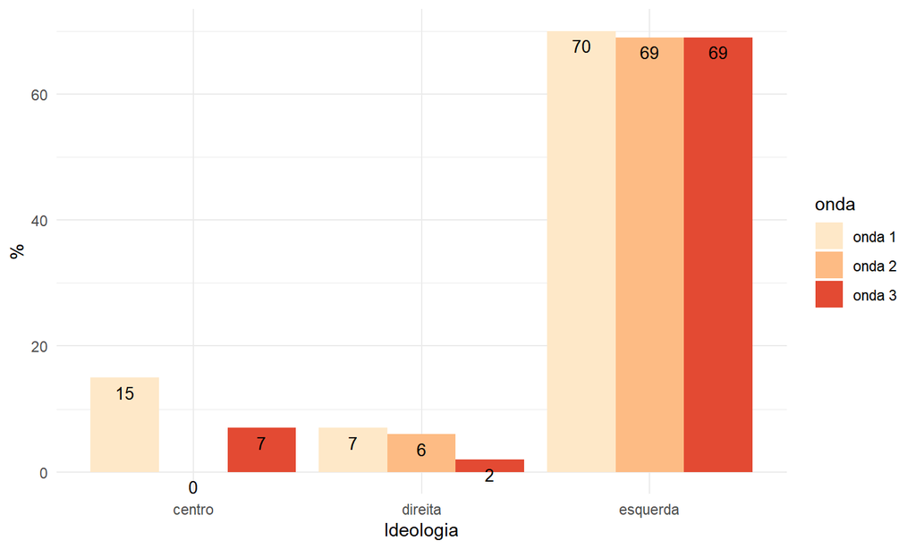

## Resultados

**Figura 2:** Defesas ao Poder Executivo na Câmara dos Deputados por espectro e por onda nos discursos que tratam de pandemia e mencionam o Executivo

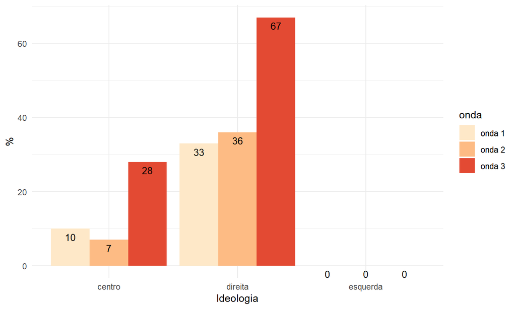

## Resultados

**Figura 3:** Ataques ao Poder Executivo no Senado Federal por espectro e por onda nos discursos que tratam de pandemia e mencionam o Executivo

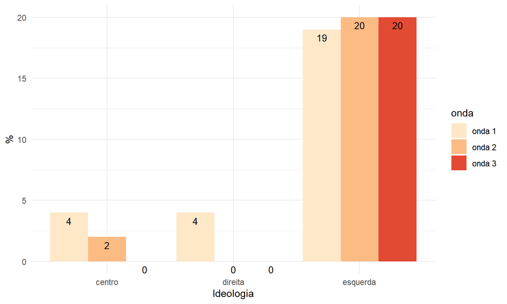

## Resultados

[figure not shown]

## Resultados

**Figura 5:** Ataque de partidos com ministério na Câmara dos Deputados por espectro e por onda nos discursos que tratam de pandemia e mencionam o Executivo

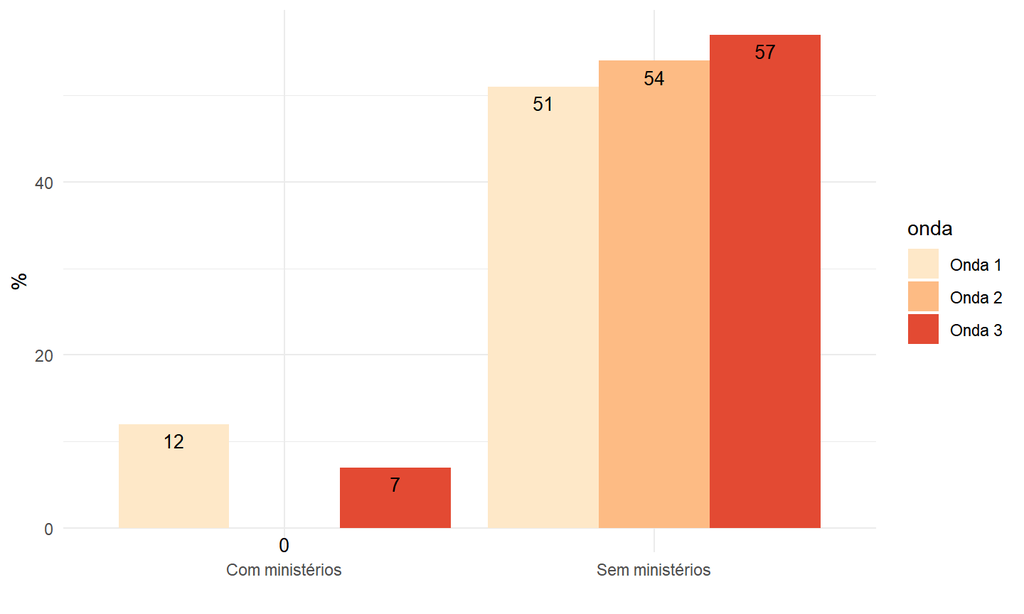

## Resultados

**Figura 6:** Defesa de partidos com ministério na Câmara dos Deputados por espectro e por onda nos discursos que tratam de pandemia e mencionam o Executivo

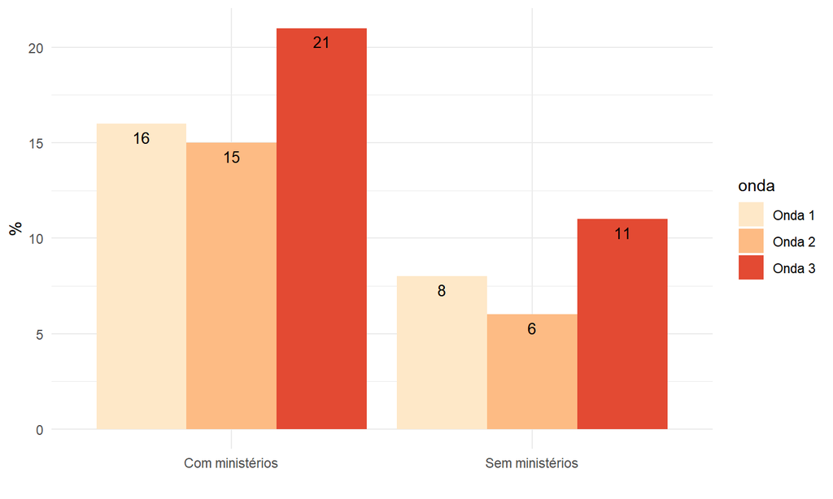

## Resultados

**Figura 7:** Apoio ao distanciamento social e auxílio econômico na Câmara dos Deputados por espectro e por onda

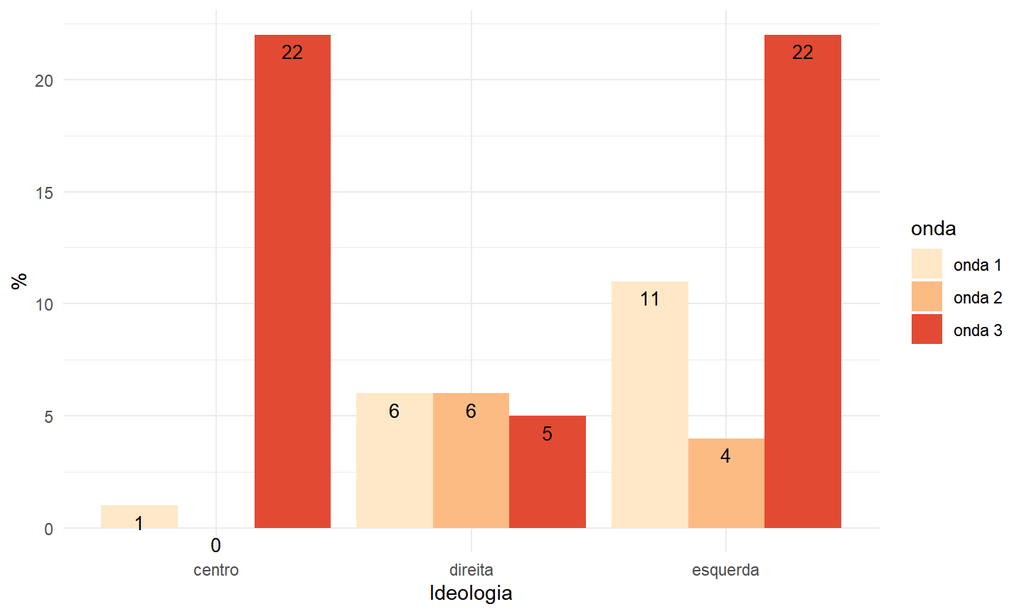

## Conclusão

O retorno da popularidade do Presidente não confirma o que a literatura prevê a respeito da não confrotação. A esquerda possui como postura consistente o conflito direto com o Presidente.

A divisão estabelecida com base nos ministérios demonstra pertinencia para a Definição dos partidos políticos

Há claramente uma organização das falas parlamentares que demonstra uma clivagem de elites a respeito da pandemia.